## Setup

### Load and clean the data

Here i focused just on the control, freshwater, pulse, press treatments in October 2016.

# Results

## How does the diversity of a local community change under our different experimental treatments?

For taxa to persist in a treatment, they must be able to grow locally or immigrate from elsewhere. Here, we compare an estimate of local (alpha) diversity for the total DNA community within each treatment.

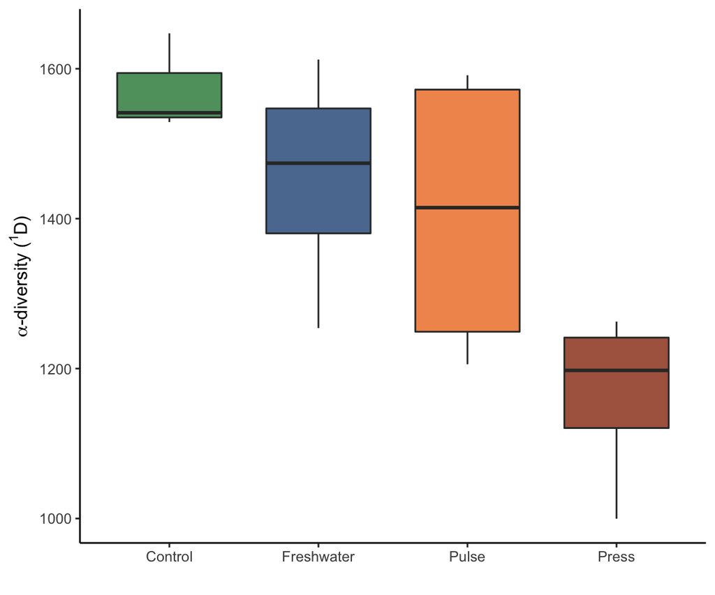

```r
otus.rich <- rowSums(decostand(otus, method = "pa"))
otus.alpha <- exp(diversity(otus, "shannon"))

data.frame(richness = otus.rich, diversity = otus.alpha) %>% rownames_to_column("sample_ID") %>%
  left_join(design) %>%
  group_by(date, treatment, molecule) %>%
  ggplot(aes(x = treatment, y = diversity, fill = treatment)) +
  # geom_point(alpha = 0.5) +
  geom_boxplot(width = .7, position = position_dodge(), alpha = .8) +
  labs(x = "", y = expression(paste(alpha,"-diversity ("^1,"D)"))) +
  scale_fill_manual(values = my.palette) +
  theme(legend.position = "none") +
  ggsave("figures/alpha.png", width = 4, height = 3, units = "in", dpi = 500)
```

```r
alpha.by.treat <- data.frame(richness = otus.rich, diversity = otus.alpha) %>% rownames_to_column("sample_ID") %>%
  left_join(design)
alpha.mod <- aov(diversity ~ treatment, data = alpha.by.treat)
summary(alpha.mod)
```

```
##             Df Sum Sq Mean Sq F value Pr(>F)
## treatment    3 320637  106879   4.869 0.0216 *
## Residuals   11 241438   21949
## ---
## Signif. codes:  0 '***' 0.001 '**' 0.01 '*' 0.05 '.' 0.1 ' ' 1
```

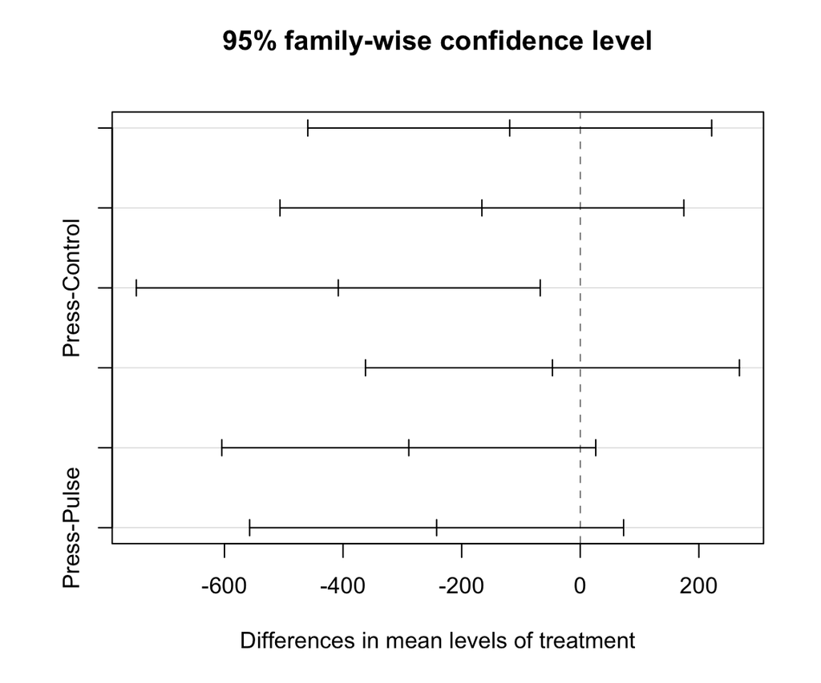

```r
plot(TukeyHSD(alpha.mod))
```

## How does saltwater addition change community structure?

Here, we want to know about the diversity among sites (beta diversity).

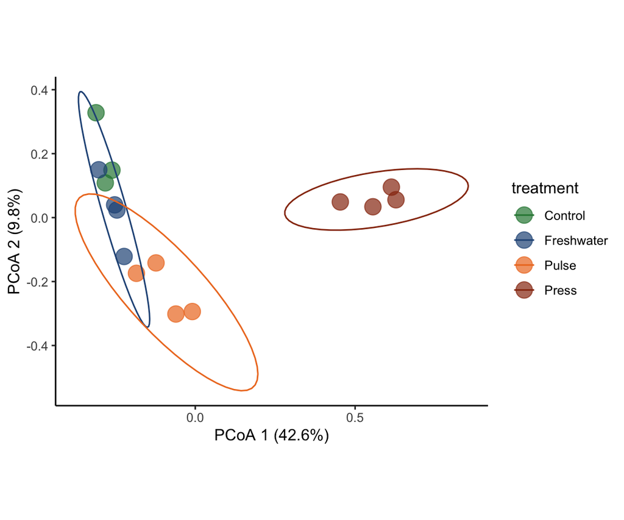

```r
otus.hel <- decostand(otus, method = "hellinger")
otus.dist <- vegdist(otus.hel, method = "euclidean")
otus.pcoa <- cmdscale(otus.dist, eig = T)
# explained variance
explained <- round(100*eigenvals(otus.pcoa)[c(1,2)]/sum(eigenvals(otus.pcoa)),1)
as.data.frame(scores(otus.pcoa)) %>%
  rownames_to_column("sample_ID") %>%
  left_join(design) %>%
  ggplot(aes(x = Dim1, y = Dim2, color = treatment)) +
  geom_point(size = 5, alpha = 0.7) +
  coord_fixed() +
  scale_color_manual(values = my.palette) +
  labs(x = paste0("PCoA 1 (", explained[1],"%)"),
       y = paste0("PCoA 2 (", explained[2],"%)")) +
  stat_ellipse() +
  ggsave("figures/ordination.png", width = 5, height = 5, units = "in", dpi = 500)
```

```r
perma.otus <- adonis(otus.hel ~ treatment, method = "euclidean", data = design)
pander(perma.otus$aov.tab)
```

Permutation: free

|  | Df | SumsOfSqs | MeanSqs | F.Model | R2 | Pr(>F) |
| --- | --- | --- | --- | --- | --- | --- |
| **treatment** | 3 | 2.367 | 0.7889 | 4.423 | 0.5468 | 0.001 |
| **Residuals** | 11 | 1.962 | 0.1784 | NA | 0.4532 | NA |
| **Total** | 14 | 4.329 | NA | NA | 1 | NA |

From this analysis, it seems that there is a gradient from freshwater, to pulse, to press treatments, with press treatments having the strongest effect on community structure. A PERMANOVA shows that treatment is a significant predictor of differences in community structure, explaining approx. 54% of the differences.

## Redundancy Analysis

We can take this a step further by constraining our ordination by environmental variables to see which variables in particular are associated with differences in community structure. We’ll perform a Redundancy Analysis (RDA).

```
## Too few points to calculate an ellipse
```

```
## Too few points to calculate an ellipse
```

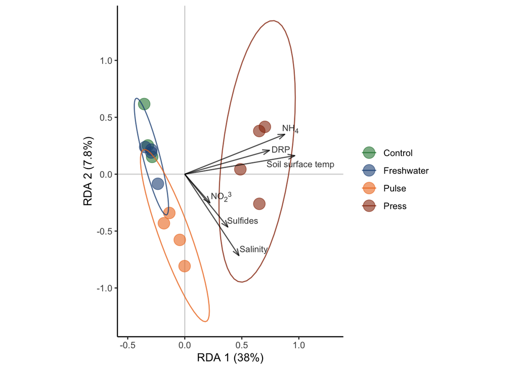

```r
env_vars <- env %>% select(DRP, NH4, NO2_3, Sulfides, Salinity, Soil_surface_temp)

rda.out <- rda(otus.hel ~ ., data = as.data.frame(scale(env_vars)))

env.vecs <- as.data.frame(rda.out$CCA$biplot[,c(1,2)])
scale.vecs <- 1
explained <- round(100*eigenvals(rda.out)[c(1,2)]/sum(eigenvals(rda.out)),1)

env.vecs$labels <- c(
  "DRP",
  "NH<sub>4</sub>",
  "NO<sub>2</sub><sup>3</sup>",
  "Sulfides",
  "Salinity",
  "Soil surface temp"
)
as.data.frame(scores(rda.out)$sites) %>%
  rownames_to_column("sample_ID") %>%
  left_join(design) %>%
  ggplot(aes(x = RDA1, y = RDA2, color = treatment)) +
  geom_hline(aes(yintercept = 0), alpha = 0.2) +
  geom_vline(aes(xintercept = 0), alpha = 0.2) +
  geom_point(size = 5, alpha = 0.6) +
  stat_ellipse(alpha = 0.8) +
  coord_fixed() +
  scale_color_manual("", values = my.palette) +
  scale_x_continuous(limits = c(-.5, 1.3)) +
  labs(x = paste0("RDA 1 (", explained[1],"%)"),
       y = paste0("RDA 2 (", explained[2],"%)")) +
  geom_segment(data = env.vecs, size = .5,
               aes(x = 0, y = 0,
                   xend = scale.vecs*RDA1,
                   yend = scale.vecs*RDA2),
               alpha = .7, color = "black",
               arrow = arrow(angle = 20,
                             length = unit(.1, "inches"),
                             type = "open")) +
  geom_richtext(alpha = 0.8, data = env.vecs, size = 3,
                  aes(x = (scale.vecs)*RDA1 + .05,
                      y = (scale.vecs)*RDA2 + .05,
                      label = env.vecs$labels),
                  color = "black",
                #label.padding = grid::unit(rep(0,4), "pt"),
                label.color = NA, fill = NA,
                nudge_y = c(-.05,-.01,0,0,0,-.13),
                nudge_x = c(0.05,0,0.05,0.08,0.08,0)) +
  ggsave("figures/rda.png", width = 7, height = 5, units = "in", dpi = 500)
```

```r
envfit(rda.out, env_vars)
```

```
##
## ***VECTORS
##
##                       RDA1     RDA2     r2 Pr(>r)
## DRP                0.96373  0.26688 0.5375  0.010 **
## NH4                0.92980  0.36807 0.8042  0.001 ***
## NO2_3              0.65848 -0.75260 0.1027  0.541
## Sulfides           0.63024 -0.77640 0.3278  0.077 .
## Salinity           0.55362 -0.83277 0.6740  0.001 ***
## Soil_surface_temp  0.98700  0.16071 0.8649  0.001 ***
## ---
## Signif. codes:  0 '***' 0.001 '**' 0.01 '*' 0.05 '.' 0.1 ' ' 1
## Permutation: free
## Number of permutations: 999
```

## Taxonomic analyses

```r
tax.expand <- tax %>% separate(taxonomy, into = c("domain", "phylum", "class", "order", "family", "genus", "species"), ",")
desulf.tax <- tax.expand %>% group_by(domain, phylum, class, order, family, genus, species) %>%
  filter(stringr::str_detect(order, "sulf")|stringr::str_detect(order, "Sulf"))
unique(desulf.tax$OTU)
```

[output not shown]

[output cut: 19 more lines]

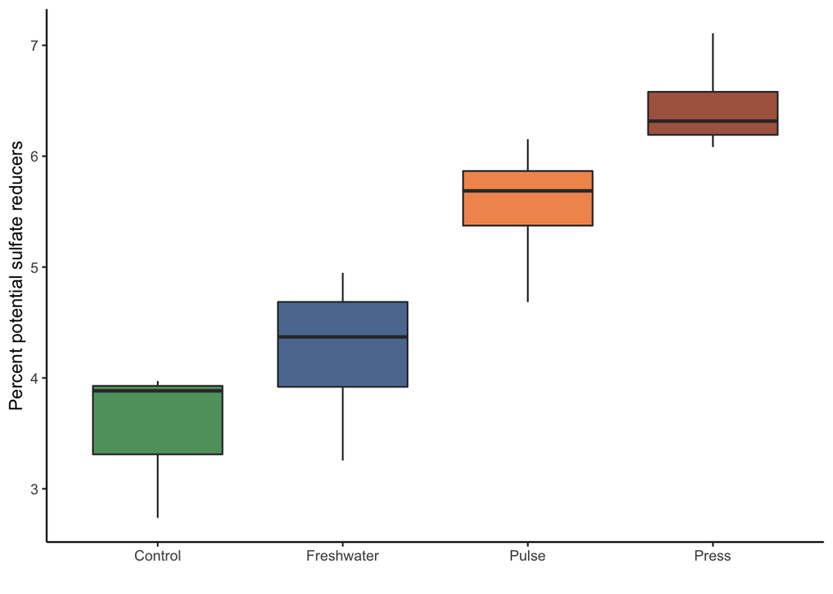

```r
desulf.cols <- which(colnames(otus) %in% paste0("otu",desulf.tax$OTU))
otus.rel <- decostand(otus, method = "total")
as.data.frame(rowSums(otus.rel[,desulf.cols])) %>%
  rownames_to_column(var = "sample_ID") %>%
  rename(sulf_percent = "rowSums(otus.rel[, desulf.cols])") %>%
  # gather(-sample_ID, key = otu, value = abundance) %>%
  left_join(design) %>%
  group_by(date, treatment, molecule) %>%
  ggplot(aes(x = treatment, y = sulf_percent*100, fill = treatment)) +
  #geom_jitter(alpha = 0.25, show.legend = F) +
  geom_boxplot(alpha = .8, width = .7) +
  #scale_y_log10() +
  scale_fill_manual(values = my.palette) +
  theme(legend.position = "none") +
  labs(y = "Percent potential sulfate reducers", x = "") +
  ggsave("figures/sulfate-reduction.png", width = 4, height = 3, units = "in", dpi = 500)
```

```r
sulf.data <- as.data.frame(rowSums(otus.rel[,desulf.cols])) %>%
  rownames_to_column(var = "sample_ID") %>%
  rename(sulf_percent = "rowSums(otus.rel[, desulf.cols])") %>%
  # gather(-sample_ID, key = otu, value = abundance) %>%
  left_join(design)
summary(aov(sulf_percent ~ treatment, data = sulf.data))
```

```
##             Df   Sum Sq   Mean Sq F value  Pr(>F)
## treatment    3 0.001849 0.0006163   15.62 0.00028 ***
## Residuals   11 0.000434 0.0000395
## ---
## Signif. codes:  0 '***' 0.001 '**' 0.01 '*' 0.05 '.' 0.1 ' ' 1
```

```r
methan.tax <- tax.expand %>% group_by(domain, phylum, class, order, family, genus, species) %>%
  filter(domain == "d:Archaea") %>%
  filter(stringr::str_detect(order, "Meth") | stringr::str_detect(genus, "Meth"))
unique(methan.tax$OTU)
```

```
##  [1]    68   121   209   268   286   295   497   758   827   876   979  1149
## [13]  1982  2103  2309  2424  2459  2904  2928  2944  3079  3722  3882  3923
## [25]  4227  4379  4500  4616  5384  5797  6665  6712  7184  7254  8390 11093
## [37] 11885 13468 14010 15042 15237 16186 17222 19094 19186 19870 22033 22354
## [49] 25908 27302 29102 30503 31126 34123 34155
```

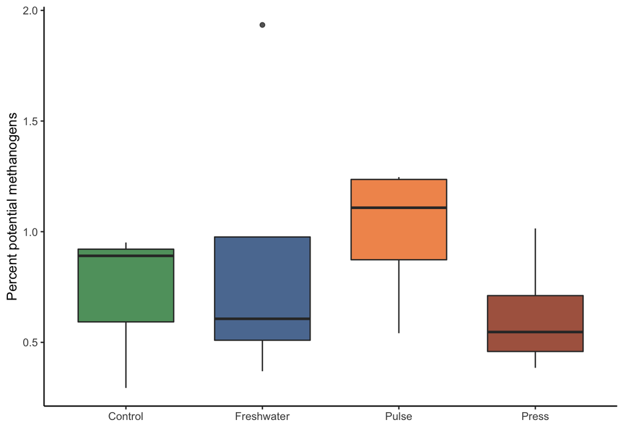

```r
methan.cols <- which(colnames(otus) %in% paste0("otu",methan.tax$OTU))
as.data.frame(rowSums(otus.rel[,methan.cols])) %>%
  rownames_to_column(var = "sample_ID") %>%
  rename(methan_percent = "rowSums(otus.rel[, methan.cols])") %>%
  # gather(-sample_ID, key = otu, value = abundance) %>%
  left_join(design) %>%
  group_by(date, treatment, molecule) %>%
  ggplot(aes(x = treatment, y = methan_percent*100, fill = treatment)) +
  #geom_jitter(alpha = 0.25, show.legend = F) +
  geom_boxplot(alpha = .8, width = 0.7) +
  scale_fill_manual(values = my.palette) +
  theme(legend.position = "none") +
  #scale_y_log10() +
  labs(y = "Percent potential methanogens", x = "") +
  ggsave("figures/methanogens.png", width = 4, height = 3, units = "in", dpi = 500)
```

```r
methan.dat <- as.data.frame(rowSums(otus.rel[,methan.cols])) %>%
  rownames_to_column(var = "sample_ID") %>%
  rename(methan_percent = "rowSums(otus.rel[, methan.cols])") %>%
  # gather(-sample_ID, key = otu, value = abundance) %>%
  left_join(design)
summary(aov(methan_percent ~ treatment, data = methan.dat))
```

```
##             Df    Sum Sq   Mean Sq F value Pr(>F)
## treatment    3 3.336e-05 1.112e-05   0.522  0.676
## Residuals   11 2.345e-04 2.132e-05
```

From this analysis, it looks like press treatments significantly affect sulfate reducers, but less so methanogens.